# Psych 254 W15 PS #1

Mike Frank

January 11, 2015

Carolyn Au (auc@)

This is problem set #1, in which we hope you will practice the packages tidyr and dplyr. There are some great cheat sheets from [RStudio](http://www.rstudio.com/resources/cheatsheets/).

## The data set

This data set comes from a replication of [Janiszewski and Uy (2008)](http://dx.doi.org/10.1111/j.1467-9280.2008.02057.x), who investigated whether the precision of the anchor for a price influences the amount of adjustment.

In the data frame, the `Input.condition` variable represents the experimental condition (under the rounded anchor, the rounded anchor, over the rounded anchor). `Input.price1`, `Input.price2`, and `Input.price3` are the anchors for the `Answer.dog_cost`, `Answer.plasma_cost`, and `Answer.sushi_cost` items.

## Preliminaries

I pretty much always clear the workspace and load the same basic helper functions before starting an analysis.

```r
rm(list=ls())
source("helper/useful.R")
```

Note that I’m using a “relative” path (the “helper”) rather than an absolute path (e.g. “/Users/mcfrank/code/projects/etc…”). The relative path means that someone else can run your code by changing to the right directory, while the absolute path will force someone else to make trivial changes every time they want to run it.

## Part 1: Data cleaning

The first part of this exercise actually just consists of getting the data in a format usable for analysis. This is not trivial. Let’s try it:

```r
d <- read.csv("data/janiszewski_rep_exercise.csv")
```

Fine, right? Why can’t we go forward with the analysis?

HINT: try computing some summary statistics for the different items. Also, are there any participants that did the task more than once?

> A quick exploration of the data in a spreadsheet and using summary(d) quickly shows that there are supposed to be 3 experimental conditions with 30 participants in each. However, there are some data in the input and answers which aren’t formatted correctly.

```r
summary(d)
```

```
##                             HITId                             HITTypeId
##  261WKUDD8XMBJ8COBQ261TO6T1XNCJ:30   2DVGTP9RA7S5C4ALLOJOM70JMHCRW9:90
##  2WQ06UFBNFSVWCUUFZWS36NG1CAH35:30
##  2XNTYMNCWYB4PXI74I8X81JONPBLPS:30
##
##
##
##
##                                           Title
##  How much is it worth? Quick 2 minute survey.:90
##
##
##
##
##
##
##                                                                 Description
##  A quick two minute survey asking about prices. DO THIS HIT ONLY ONCE.:90
##
##
##
##
##
##
##                   Keywords      Reward
##  survey, quick, prices:90   Min.   :0.1
##                             1st Qu.:0.1
##                             Median :0.1
##                             Mean   :0.1
##                             3rd Qu.:0.1
##                             Max.   :0.1
##
##                        CreationTime MaxAssignments
##  Wed Jan 25 18:13:24 GMT 2012:90    Min.   :30
##                                     1st Qu.:30
##                                     Median :30
##                                     Mean   :30
##                                     3rd Qu.:30
##                                     Max.   :30
##
```

[output cut: 65 more lines]

```
##  over   :30      4,988:30     2,492:30     Min.   :8.64   2000   :27
##  rounded:30      5,000:30     2,500:30     1st Qu.:8.64   2200   : 8
##  under  :30      5,012:30     2,508:30     Median :9.00   1000   : 6
##                                            Mean   :9.00   1500   : 6
##                                            3rd Qu.:9.36   1900   : 4
##                                            Max.   :9.36   2250   : 3
##                                                           (Other):36
##  Answer.plasma_cost Answer.sushi_cost
##  4500   :16         8      :18
##  4000   : 9         8.5    :12
##  3500   : 6         7.5    :10
##  4700   : 5         7.99   : 9
##  2500   : 4         8.99   : 4
##  4800   : 4         6.99   : 3
##  (Other):46         (Other):34
```

> This is confirmed by checking levels for the Answer columns above, e.g.:

```r
levels(d$Answer.dog_cost)
```

```
##  [1] "1000"         "1500"         "1600"         "1658"
##  [5] "1687"         "1700"         "1749"         "1750"
##  [9] "1790"         "1800"         "1850"         "1875"
## [13] "1900"         "1950"         "1990"         "2,000"
## [17] "2000"         "2100"         "2192"         "2200"
## [21] "2250"         "2292"         "2299"         "2300"
## [25] "2325"         "2350"         "2400"         "2450"
## [29] "2482"         "2499.99"      "2500"         "500"
## [33] "800"          "five hundred"
```

```r
levels(d$Answer.plasma_cost)
```

```
##  [1] "0.45"    "1200"    "1500"    "2000"    "2500"    "2999"    "3000"
##  [8] "3200"    "3250"    "3258"    "3458"    "3499"    "3500"    "3800"
## [15] "4,000"   "4000"    "4120"    "4200"    "4300"    "4350"    "4400"
## [22] "4495"    "4500"    "4540"    "4578"    "4600"    "4650"    "4675"
## [29] "4699"    "4700"    "4750"    "4800"    "4849"    "4850"    "4888"
## [36] "4899"    "4900"    "4968"    "4995"    "4997"    "4999"    "4999.99"
## [43] "5000"
```

```r
levels(d$Answer.sushi_cost)
```

```
##  [1] ""       "6.5"    "6.78"   "6.95"   "6.99"   "7"      "7,75"
##  [8] "7.02"   "7.35"   "7.5"    "7.56"   "7.58"   "7.69"   "7.75"
## [15] "7.8"    "7.89"   "7.99"   "8"      "8.25"   "8.46"   "8.49"
## [22] "8.5"    "8.69"   "8.7"    "8.95"   "8.99"   "9"      "9.3"
## [29] "ehight"
```

> To fix that (and convert the levels to numeric values):

```r
d$Answer.dog_cost <- revalue(d$Answer.dog_cost, c("five hundred"=500, "2,000"=2000))
d$Answer.sushi_cost <- revalue(d$Answer.sushi_cost, c("7,75"=7.75, "ehight"=8))
d$Answer.plasma_cost <- revalue(d$Answer.plasma_cost, c("4,000"=4000, "0.45"=4500))

d$Answer.dog_cost <- as.numeric(as.character(d$Answer.dog_cost))
d$Answer.sushi_cost <- as.numeric(as.character(d$Answer.sushi_cost))
d$Answer.plasma_cost <- as.numeric(as.character(d$Answer.plasma_cost))
```

> The input prices are also read in as strings because of the commas.

```r
d$Input.price1 <- as.numeric(gsub(",","", d$Input.price1))
d$Input.price2 <- as.numeric(gsub(",","", d$Input.price2))
d$Input.price3 <- as.numeric(gsub(",","", d$Input.price3))
```

> Additionally, the summary clearly shows that 2 participants completed the task more than once. To fix this, we can keep only the first result for each participant.

```r
d[which(d$WorkerId == "A1VYX5VKZ0CTWU"),]
```

```
##                             HITId                      HITTypeId
## 23 261WKUDD8XMBJ8COBQ261TO6T1XNCJ 2DVGTP9RA7S5C4ALLOJOM70JMHCRW9
## 48 2WQ06UFBNFSVWCUUFZWS36NG1CAH35 2DVGTP9RA7S5C4ALLOJOM70JMHCRW9
## 62 2XNTYMNCWYB4PXI74I8X81JONPBLPS 2DVGTP9RA7S5C4ALLOJOM70JMHCRW9
##                                           Title
## 23 How much is it worth? Quick 2 minute survey.
## 48 How much is it worth? Quick 2 minute survey.
## 62 How much is it worth? Quick 2 minute survey.
##                                                              Description
## 23 A quick two minute survey asking about prices. DO THIS HIT ONLY ONCE.
## 48 A quick two minute survey asking about prices. DO THIS HIT ONLY ONCE.
## 62 A quick two minute survey asking about prices. DO THIS HIT ONLY ONCE.
##                 Keywords Reward                 CreationTime
## 23 survey, quick, prices    0.1 Wed Jan 25 18:13:24 GMT 2012
## 48 survey, quick, prices    0.1 Wed Jan 25 18:13:24 GMT 2012
```

[output cut: 37 more lines]

```r
d <- subset(d, AssignmentId != "2IBHSTLB3L0FR1IX01AEQREVGHDIU3" & AssignmentId != "22LLB3L0FBJ9Y6KYQ9IE2E5RR3PXLP")

d[which(d$WorkerId == "A5IUO2T5MZQUZ"),]
```

```
##                             HITId                      HITTypeId
## 22 261WKUDD8XMBJ8COBQ261TO6T1XNCJ 2DVGTP9RA7S5C4ALLOJOM70JMHCRW9
## 58 2WQ06UFBNFSVWCUUFZWS36NG1CAH35 2DVGTP9RA7S5C4ALLOJOM70JMHCRW9
##                                           Title
## 22 How much is it worth? Quick 2 minute survey.
## 58 How much is it worth? Quick 2 minute survey.
##                                                              Description
## 22 A quick two minute survey asking about prices. DO THIS HIT ONLY ONCE.
## 58 A quick two minute survey asking about prices. DO THIS HIT ONLY ONCE.
##                 Keywords Reward                 CreationTime
## 22 survey, quick, prices    0.1 Wed Jan 25 18:13:24 GMT 2012
## 58 survey, quick, prices    0.1 Wed Jan 25 18:13:24 GMT 2012
##    MaxAssignments RequesterAnnotation AssignmentDurationInSeconds
## 22             30    Department:Other                         600
## 58             30    Department:Other                         600
##    AutoApprovalDelayInSeconds                   Expiration
## 22                     604800 Wed Feb 01 18:13:24 GMT 2012
## 58                     604800 Wed Feb 01 18:13:24 GMT 2012
##    NumberOfSimilarHITs LifetimeInSeconds                   AssignmentId
## 22                   2                NA 2RSJPPSI2KYE5314JVBLT6WJ500QKL
## 58                   3                NA 2WL6YTWX4H3HI7KJPZ0GP6IJTNW3YR
##         WorkerId AssignmentStatus                   AcceptTime
## 22 A5IUO2T5MZQUZ        Submitted Thu Jan 26 23:48:06 GMT 2012
## 58 A5IUO2T5MZQUZ        Submitted Thu Jan 26 23:45:29 GMT 2012
##                      SubmitTime             AutoApprovalTime ApprovalTime
## 22 Thu Jan 26 23:50:11 GMT 2012 Thu Feb 02 15:50:11 PST 2012           NA
## 58 Thu Jan 26 23:47:53 GMT 2012 Thu Feb 02 15:47:53 PST 2012           NA
##    RejectionTime RequesterFeedback WorkTimeInSeconds LifetimeApprovalRate
## 22            NA                NA               125             0% (0/0)
## 58            NA                NA               144             0% (0/0)
##    Last30DaysApprovalRate Last7DaysApprovalRate Input.condition
## 22               0% (0/0)              0% (0/0)            over
## 58               0% (0/0)              0% (0/0)           under
##    Input.price1 Input.price2 Input.price3 Answer.dog_cost
## 22         5012         2508         9.36            2000
## 58         4988         2492         8.64            2000
##    Answer.plasma_cost Answer.sushi_cost
## 22               4500              8.50
## 58               4500              7.99
```

```r
d <- subset(d, AssignmentId != "2RSJPPSI2KYE5314JVBLT6WJ500QKL")
```

> We could also drop AssignmentId=2C2ESCWY2AOOIYV1Q6FONQSCOG111N as well, since it has an incomplete answer for sushi_cost and was completed in only 18s.

```r
d <- subset(d, AssignmentId != "2C2ESCWY2AOOIYV1Q6FONQSCOG111N")
```

> To confirm that the fixes were done correctly:

```r
summary(d)
```

```
##                             HITId                             HITTypeId
##  261WKUDD8XMBJ8COBQ261TO6T1XNCJ:28   2DVGTP9RA7S5C4ALLOJOM70JMHCRW9:86
##  2WQ06UFBNFSVWCUUFZWS36NG1CAH35:29
##  2XNTYMNCWYB4PXI74I8X81JONPBLPS:29
##
##
##
##
##                                           Title
##  How much is it worth? Quick 2 minute survey.:86
##
##
##
##
##
##
##                                                                 Description
##  A quick two minute survey asking about prices. DO THIS HIT ONLY ONCE.:86
##
##
##
##
##
##
##                   Keywords      Reward
##  survey, quick, prices:86   Min.   :0.1
##                             1st Qu.:0.1
##                             Median :0.1
##                             Mean   :0.1
##                             3rd Qu.:0.1
##                             Max.   :0.1
##
##                        CreationTime MaxAssignments
##  Wed Jan 25 18:13:24 GMT 2012:86    Min.   :30
##                                     1st Qu.:30
##                                     Median :30
##                                     Mean   :30
##                                     3rd Qu.:30
##                                     Max.   :30
##
```

[output cut: 65 more lines]

```
##  over   :28      Min.   :4988   Min.   :2492   Min.   :8.640
##  rounded:29      1st Qu.:4988   1st Qu.:2492   1st Qu.:8.640
##  under  :29      Median :5000   Median :2500   Median :9.000
##                  Mean   :5000   Mean   :2500   Mean   :8.996
##                  3rd Qu.:5012   3rd Qu.:2508   3rd Qu.:9.360
##                  Max.   :5012   Max.   :2508   Max.   :9.360
##
##  Answer.dog_cost Answer.plasma_cost Answer.sushi_cost
##  Min.   : 500    Min.   :1200       Min.   :6.500
##  1st Qu.:1760    1st Qu.:3850       1st Qu.:7.607
##  Median :2000    Median :4500       Median :8.000
##  Mean   :1895    Mean   :4142       Mean   :8.004
##  3rd Qu.:2200    3rd Qu.:4700       3rd Qu.:8.500
##  Max.   :2500    Max.   :5000       Max.   :9.300
##
```

## Part 2: Making these data tidy

Now let’s start with the cleaned data, so that we are all beginning from the same place.

```r
d <- read.csv("data/janiszewski_rep_cleaned.csv")
d <- subset(d, WorkerId != "A3S99S9NJ6X08J") # drop row with NA sushi cost
```

This data frame is in *wide* format - that means that each row is a participant and there are multiple observations per participant. This data is not *tidy*.

To make this data tidy, we’ll do some cleanup. First, remove the columns you don’t need, using the verb `select`.

HINT: `?select` and the examples of helper functions will help you be efficient.

```r
d.tidy <- d %>%
  select(WorkerId, Input.condition,
         starts_with("Answer"),
         starts_with("Input"))
```

Try renaming some variables using `rename`. A good naming scheme is:

- consistent with case
- consistent with “.” or “_" ( “_" is usually preferred)
- concise as will be comprehensible to others

Try using the `%>%` operator as well. So you will be “piping” `d %>% rename(...)`.

```r
d.tidy <- d.tidy %>%
  rename(workerid = WorkerId,
         condition = Input.condition,
         plasma_anchor = Input.price1,
         dog_anchor = Input.price2,
         sushi_anchor = Input.price3,
         dog_cost = Answer.dog_cost,
         plasma_cost = Answer.plasma_cost,
         sushi_cost = Answer.sushi_cost)
```

OK, now for the tricky part. Use the verb *gather* to turn this into a *tidy* data frame.

HINT: look for online examples!

```r
d.tidy <- d.tidy %>%
  gather(item, cost,
         dog_anchor, plasma_anchor, sushi_anchor,
         dog_cost, plasma_cost, sushi_cost)
```

Bonus problem: *spread* these data back into a wide format data frame.

```r
d.wide <- d.tidy %>%
  spread(item, cost)
```

## Part 3: Manipulating the data using dplyr

NOTE: If you generally use `plyr` package, note that they do not play nicely together so things like the rename function won’t work unless you load `dplyr` after `plyr`.

As we said in class, a good thing to do is always to check histograms of the response variable. Do that now, using either regular base graphics or ggplot. What can you conclude?

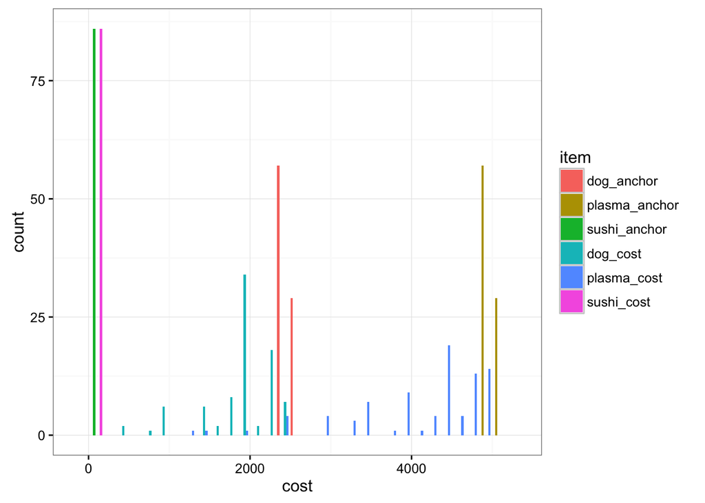

```r
ggplot(d.tidy, aes(x=cost, fill=item)) +
    geom_histogram(position=position_dodge())
```

> The data is difficult to interpret because of the different scales. If we allow for different scales with each item, we can interpret the sushi data better. However, it looks like there might not be any correlations between conditions and outcomes.

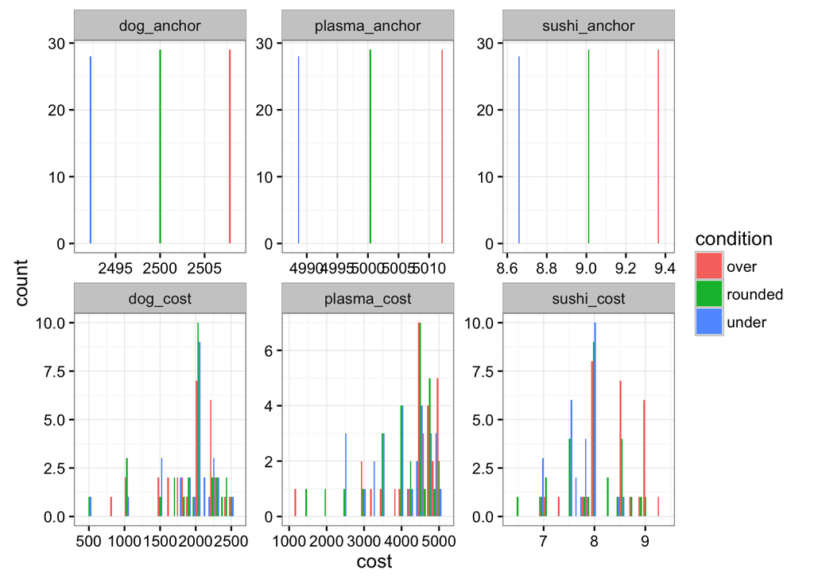

```r
ggplot(data=d.tidy, aes(x=cost, fill=condition)) +
facet_wrap(~item, scale="free") +
geom_histogram(position="dodge")
```

Try also using the dplyr `distinct` function to remove the duplicate participants from the raw csv file that you discovered in part 1.

```r
d.raw <- read.csv("data/janiszewski_rep_exercise.csv")
d.unique.subs <- distinct(d.raw, WorkerId)
```

OK, now we turn to the actual data anlysis. We’ll be using dplyr verbs to *filter*, *group*,*mutate*, and *summarise* the data.

Start by using *summarise* to compute the grand mean bet. (Note that this is the same as taking the grant mean - the value will come later. Right now we’re just learning the syntax of that verb.)

```r
grouped <- group_by(d.tidy, item)
summarise(grouped, mean=mean(cost))
```

```
## Source: local data frame [6 x 2]
##
##            item        mean
##          (fctr)       (dbl)
## 1    dog_anchor 2500.093023
## 2 plasma_anchor 5000.139535
## 3  sushi_anchor    9.004186
## 4      dog_cost 1895.278953
## 5   plasma_cost 4141.651047
## 6    sushi_cost    8.009884
```

This is a great time to get comfortable with the %>% operator. In brief, %>% allows you to pipe data from one function to another. So if you would have written:

`d <- function(d, other_stuff)`

you can now write:

`d <- d %>% function(other_stufF)`

That doesn’t seem like much, but it’s cool when you can replace:

`d <- function1(d, other_stuff) d <- function2(d, lots_of_other_stuff, more_stuff) d <- function3(d, yet_more_stuff)`

with

`d <- d %>% function1(other_stuff) %>% function2(lots_of_other_stuff, more_stuff) %>% function3(yet_more_stuff)`

In other words, you get to make a clean list of the things you want to do and chain them together without a lot of intermediate assignments.

Let’s use that capacity to combine summarise with *group_by*, which allows us to break up our summary into groups. Try grouping by item and condition and taking means using *summarise*, chaining these two verbs with %>%.

```r
group_by(d.tidy, item) %>%
summarise(mean=mean(cost))
```

```
## Source: local data frame [6 x 2]
##
##            item        mean
##          (fctr)       (dbl)
## 1    dog_anchor 2500.093023
## 2 plasma_anchor 5000.139535
## 3  sushi_anchor    9.004186
## 4      dog_cost 1895.278953
## 5   plasma_cost 4141.651047
## 6    sushi_cost    8.009884
```

OK, it’s looking like there are maybe some differences between conditions, but how are we going to plot these? They are fundamentally different magnitudes from one another.

Really we need the size of the deviation from the anchor, which means we need the anchor value. Let’s go back to the data and add that in.

Take a look at this complex expression. You don’t have to modify it, but see what is being done here with gather, separate and spread. Run each part (e.g. the first verb, the first two verbs, etc.) and after doing each, look at head(d.tidy) to see what they do.

```r
d.tidy <- d %>%
  select(WorkerId, Input.condition,
         starts_with("Answer"),
         starts_with("Input")) %>%
  rename(workerid = WorkerId,
         condition = Input.condition,
         plasma_anchor = Input.price1,
         dog_anchor = Input.price2,
         sushi_anchor = Input.price3,
         dog_cost = Answer.dog_cost,
         plasma_cost = Answer.plasma_cost,
         sushi_cost = Answer.sushi_cost) %>%
  gather(name, cost,
         dog_anchor, plasma_anchor, sushi_anchor,
         dog_cost, plasma_cost, sushi_cost) %>%
  separate(name, c("item", "type"), "_") %>%
  spread(type, cost)
```

Now we can do the same thing as before but look at the relative difference between anchor and estimate. Let’s do this two ways:

- By computing absolute percentage change in price, and
- By computing z-scores over items.

To do the first, use the *mutate* verb to add a percent change column, then comute the same summary as before.

```r
pcts <- d.tidy %>%
  mutate(pct_change = (cost - anchor) * 100 /anchor)
pcts %>%
  group_by(item, condition) %>%
  summarise(mean = mean(pct_change))
```

```
## Source: local data frame [9 x 3]
## Groups: item [?]
##
##     item condition      mean
##    (chr)    (fctr)     (dbl)
## 1    dog      over -24.45004
## 2    dog   rounded -24.62070
## 3    dog     under -23.47655
## 4 plasma      over -13.99263
## 5 plasma   rounded -18.16690
## 6 plasma     under -19.43951
## 7  sushi      over -11.08532
## 8  sushi   rounded -11.60536
## 9  sushi     under -10.38773
```

To do the second, you will need to *group* once by item, then to *ungroup* and do the same thing as before. NOTE: you can use group_by(…, add=FALSE) to set new grouping levels, also.

HINT: `scale(x)` returns a complicated data structure that doesn’t play nicely with dplyr. try `scale(x)[,1]` to get what you need.

```r
z.scores <- d.tidy %>%
  group_by(item) %>%
  mutate(mu = mean(cost), sd = sd(cost)) %>%
  ungroup() %>%
  mutate(z = (cost - mu) / sd)

z.scores %>% group_by(item, condition, add=FALSE) %>%
 summarize("mean z" = mean(z))
```

```
## Source: local data frame [9 x 3]
## Groups: item [?]
##
##     item condition       mean z
##    (chr)    (fctr)        (dbl)
## 1    dog      over -0.001122492
## 2    dog   rounded -0.024943970
## 3    dog     under  0.026997407
## 4 plasma      over  0.203178138
## 5 plasma   rounded -0.060093309
## 6 plasma     under -0.148195001
## 7  sushi      over  0.533144790
## 8  sushi   rounded -0.092743732
## 9  sushi     under -0.456129667
```

OK, now here comes the end: we’re going to plot the differences and see if anything happened. First the percent change:

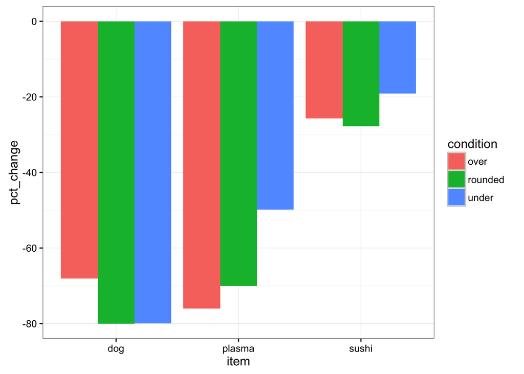

```r
ggplot(pcts, aes(x = item, y = pct_change, fill =condition )) +
   geom_bar(position = position_dodge(), stat = "identity")
```

and the z-scores:

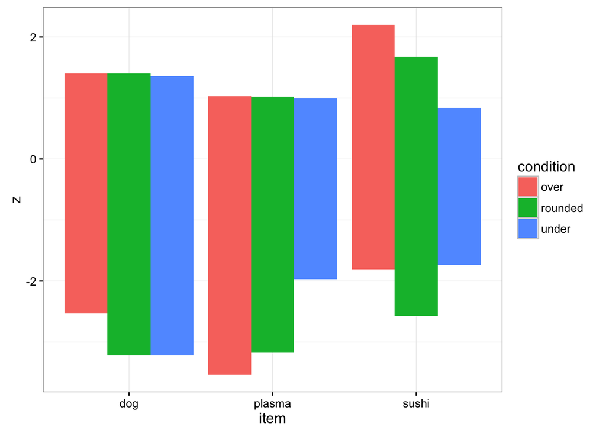

```r
ggplot(z.scores, aes(x = item, y = z, fill =condition )) +
   geom_bar(position = position_dodge(), stat = "identity")
```

Oh well. This replication didn’t seem to work out straightforwardly.